# Laboratorio 1

Maria del Carmen Carranza Montero

9/1/2020

## Ejercicio 1.3

#### 1)Leer el archivo shape storms_xyz_feature del directorio shape del paquete sf

```r
list.files(system.file("shape/", package = "sf"))
```

```
##  [1] "nc.dbf"                  "nc.prj"
##  [3] "nc.shp"                  "nc.shx"
##  [5] "olinda1.dbf"             "olinda1.prj"
##  [7] "olinda1.shp"             "olinda1.shx"
##  [9] "storms_xyz.dbf"          "storms_xyz.shp"
## [11] "storms_xyz.shx"          "storms_xyz_feature.dbf"
## [13] "storms_xyz_feature.shp"  "storms_xyz_feature.shx"
## [15] "storms_xyzm.dbf"         "storms_xyzm.shp"
## [17] "storms_xyzm.shx"         "storms_xyzm_feature.dbf"
## [19] "storms_xyzm_feature.shp" "storms_xyzm_feature.shx"
```

```r
system.file("shape", package="sf") %>% st_layers()
```

```
## Driver: ESRI Shapefile
## Available layers:
##            layer_name        geometry_type features fields
## 1                  nc              Polygon      100     14
## 2             olinda1              Polygon      470      6
## 3          storms_xyz       3D Line String       71      0
## 4         storms_xyzm Measured Line String       71      0
## 5 storms_xyzm_feature Measured Line String       71      1
## 6  storms_xyz_feature       3D Line String       71      1
```

```r
system.file("shape/storms_xyz_feature.shp", package="sf") %>%
read_sf() -> storms_xyz;storms_xyz
```

```
## Simple feature collection with 71 features and 1 field
## geometry type:  LINESTRING
## dimension:      XYZ
## bbox:           xmin: -102.2 ymin: 8.3 xmax: 0 ymax: 59.5
## z_range:        zmin: 924 zmax: 1017
## CRS:            NA
## # A tibble: 71 x 2
##    Track                                                                geometry
##    <chr>                                                            <LINESTRING>
##  1 TONY    Z (-50.8 20.1 1011, -51.2 20.4 1011, -51.5 20.8 1010, -51.7 21.3 100~
##  2 SANDY   Z (-77.4 14.3 1006, -77.8 13.9 1005, -78.2 13.5 1003, -78.6 13.1 100~
##  3 RAFAEL  Z (-62.7 14.7 1006, -63.2 15 1007, -63.7 15.3 1006, -63.8 15.6 1006,~
##  4 PATTY   Z (-72.5 25.5 1012, -72.4 25.4 1010, -72.2 25.4 1009, -72.2 25.5 100~
##  5 OSCAR   Z (-38 12.4 1008, -38.7 13.6 1008, -39.6 15 1007, -40.5 16.3 1006, -~
##  6 NADINE  Z (-38 15.5 1008, -39.4 15.6 1007, -40.8 15.8 1007, -41.9 16 1007, -~
##  7 MICHAEL Z (-36.7 28.9 1015, -37.9 28.1 1015, -39.2 27.2 1015, -40.1 26.4 101~
##  8 LESLIE  Z (-27.4 12.9 1010, -29.6 13 1010, -31.7 13.1 1009, -33.7 13.2 1009,~
##  9 KIRK    Z (-43.4 23.9 1007, -44.5 24 1004, -45.5 24.3 1003, -46.3 24.6 1001,~
## 10 JOYCE   Z (-31.7 10.7 1011, -33.1 11.1 1011, -34.5 11.5 1011, -35.8 12.1 100~
## # ... with 61 more rows
```

#### 2)Copie este archivo en otro directorio de su computadora y léalo desde allí (nota: ¡un shapefile consta de más de un archivo!)

```r
#save(storms_xyz, file ="tormentas.rda")

#load(file = "C:/Users/carme/Desktop/Maestria-Estadística/2020/Segundo semestre/Espacial/Lab1_Carmen")
```

#### 3)¿Cuántas características contiene este conjunto de datos?

```r
class(st_geometry(storms_xyz))
```

```
## [1] "sfc_LINESTRING" "sfc"
```

```r
dim(storms_xyz)
```

```
## [1] 71  2
```

```r
summary(storms_xyz)
```

```
##     Track                   geometry
##  Length:71          LINESTRING Z:71
##  Class :character   epsg:NA     : 0
##  Mode  :character
```

#### 4) Grafique el conjunto de datos con axes = TRUE (pista: antes de graficar, canalice st_zm para soltar las coordenadas Z y M; más sobre esto en el capítulo 3).

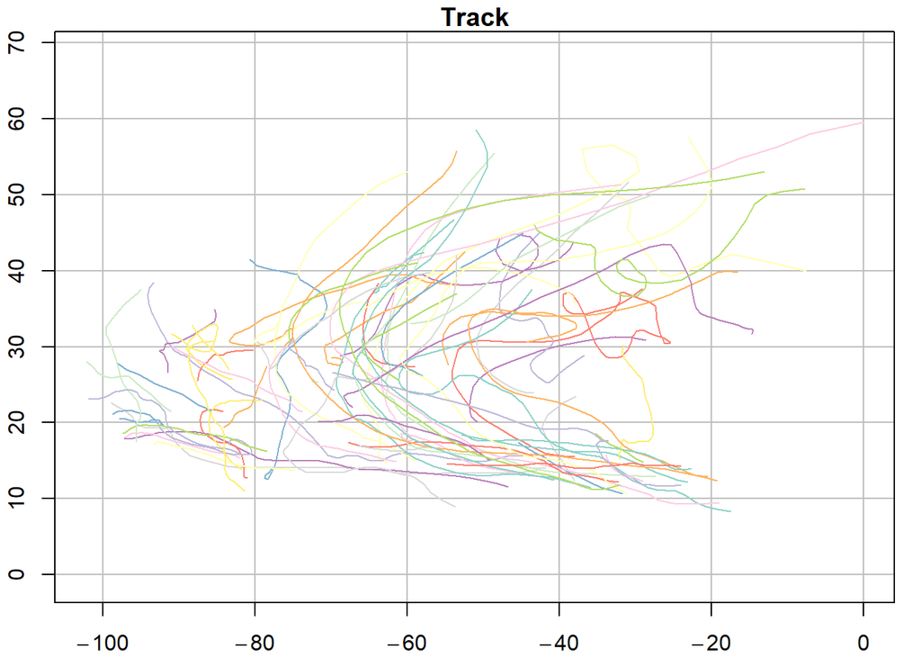

```r
system.file("shape/storms_xyz_feature.shp", package="sf") %>%
  read_sf() %>%
  st_zm() %>%
  plot(graticule = TRUE, axes = TRUE)
```

#### 5) Antes de trazar, canalice el conjunto de datos st_set_crs(4326). ¿Qué hay de diferente en el gráfico obtenido?

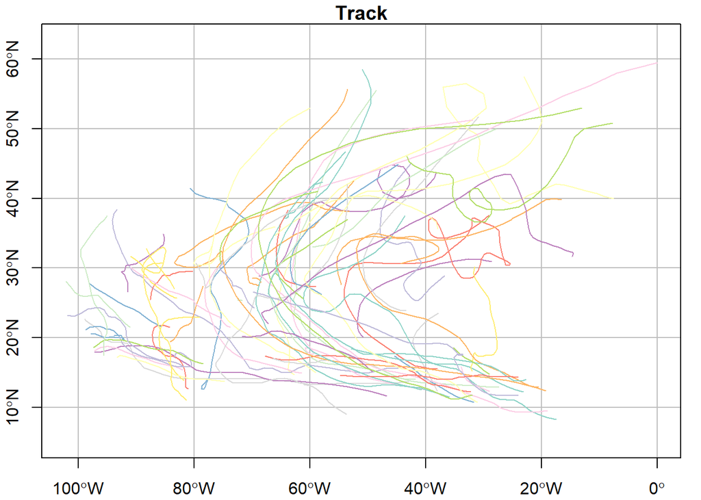

```r
system.file("shape/storms_xyz_feature.shp", package="sf") %>%
  read_sf() %>%
  st_zm() %>%
  st_set_crs(4326) %>%
  plot(graticule = TRUE, axes = TRUE)
```

```r
#En el primer gráfico se obseva que el eje x va de -100 a 0 y en el eje y va de 10 a 60, en el segundo gráfico se puede observar grados y puntos cardinales para ubicar las tormentas, información más útil que el primer gráfico.
```

## Ejercicio 2.6

#### 1) Convertir los puntos (x, y): (10,2),(- 10,-2),(10,-2) y (0,10) a coordenadas polares

```r
x1 <- 10
y1 <- 2
x2 <- -10
y2 <- -2
x3 <- 10
y3 <- -2
x4 <- 0
y4 <- 10

round((r1 <- sqrt(x1^2 + y1^2)),3)
```

```
## [1] 10.198
```

```r
round((theta1 <- atan(y1/x1)),3)
```

```
## [1] 0.197
```

```r
round((r2 <- sqrt(x2^2 + y2^2)),3)
```

```
## [1] 10.198
```

```r
round((theta2 <- atan(y2/x2)),3)
```

```
## [1] 0.197
```

```r
round((r3 <- sqrt(x3^2 + y3^2)),3)
```

```
## [1] 10.198
```

```r
round((theta3 <- atan(y3/x3)),3)
```

```
## [1] -0.197
```

```r
round((r4 <- sqrt(x4^2 + y4^2)),3)
```

```
## [1] 10
```

```r
round((theta4 <- atan(y4/x4)),3)
```

```
## [1] 1.571
```

Por lo tanto para los pares (r,ϕ),se obtienen (10.198, 0.197), (10.198,0.197), (10.198,-0.197),(10, 1.571).

#### 2) Convertir los puntos polares $(r,\phi)$: (10,45°),(0,100°) y (5,359°) en coordenadas cartesianas

```r
r5 <- 10
phi5 <- 45
r6 <- 0
phi6 <- 100
r7 <- 5
phi7 <- 359

x5 <- r5*cos(phi5)
y5 <- r5*sin(phi5)

x6 <- r6*cos(phi6)
y6 <- r6*sin(phi6)

x7 <- r7*cos(phi7)
y7 <- r7*sin(phi7)

(cc5 <- round(cbind(x5,y5),3))
```

```
##         x5    y5
## [1,] 5.253 8.509
```

```r
(cc6 <- round(cbind(x6,y6),3))
```

```
##      x6 y6
## [1,]  0  0
```

```r
(cc7 <- round(cbind(x7,y7),3))
```

```
##         x7    y7
## [1,] 3.268 3.784
```

#### 2) Suponiendo que la Tierra es una esfera con un radio de 6371 km, calcule para $(\lambda, \theta)$ que señala la distancia del gran circulo entre (10,10) y (11,10), entre (10,80) y (11,80), entre (10,10) y (10,11) y entre (10,80) y (10,81) (unidades : grados) ¿Cuales son las unidades de distancia?

#### Transformación a radianes

```r
pi <- 3.14159265359


lambda1 <- 10*(pi/180)
theta1 <- 10*(pi/180)
lambda2 <- 11*(pi/180)
theta2 <- 10*(pi/180)

lambda3 <- 10*(pi/180)
theta3 <- 80*(pi/180)
lambda4 <- 11*(pi/180)
theta4 <- 80*(pi/180)

lambda5 <- 10*(pi/180)
theta5 <- 10*(pi/180)
lambda6 <- 10*(pi/180)
theta6 <- 11*(pi/180)

lambda7 <- 10*(pi/180)
theta7 <- 80*(pi/180)
lambda8 <- 10*(pi/180)
theta8 <- 81*(pi/180)

r <- 6371

#Distancia entre arco (10,10) y (11,10)
theta_1 <- acos(sin(theta1)*sin(theta2)+cos(theta1)*cos(theta2)*cos(abs(lambda1-lambda2)))
primero <- r*theta_1
primero_grados <- (primero*180)/pi

#Distancia entre arco (10,80) y (11,80)
theta_2 <- acos(sin(theta3)*sin(theta4)+cos(theta3)*cos(theta4)*cos(abs(lambda3-lambda4)))
segundo <- r*theta_2
segundo_grados <- (segundo*180)/pi

#Distancia entre arco (10,10) y (10,11)
theta_3 <- acos(sin(theta5)*sin(theta6)+cos(theta5)*cos(theta6)*cos(abs(lambda5-lambda6)))
tercero <- r*theta_3
tercero_grados <- (tercero*180)/pi

#Distancia entre arco (10,80) y (10,81)
theta_4 <- acos(sin(theta7)*sin(theta8)+cos(theta7)*cos(theta8)*cos(abs(lambda7-lambda8)))
cuarto <- r*theta_4
cuarto_grados <- (cuarto*180)/pi

(radianes <- round(cbind(primero, segundo, tercero, cuarto),1)/1000)
```

```
##      primero segundo tercero cuarto
## [1,]  0.1095  0.0193  0.1112 0.1112
```

```r
(grados <- round(cbind(primero_grados, segundo_grados, tercero_grados, cuarto_grados),1)/1000)
```

```
##      primero_grados segundo_grados tercero_grados cuarto_grados
## [1,]         6.2742         1.1063          6.371         6.371
```